# Quicksort Scalability

Giulio Fantuzzi

# OMP: original version vs L1-optimized version

**NOTE** These data have been collected using a total size of $N=640.000.000$

Plot of the average sorting time vs number of threads:

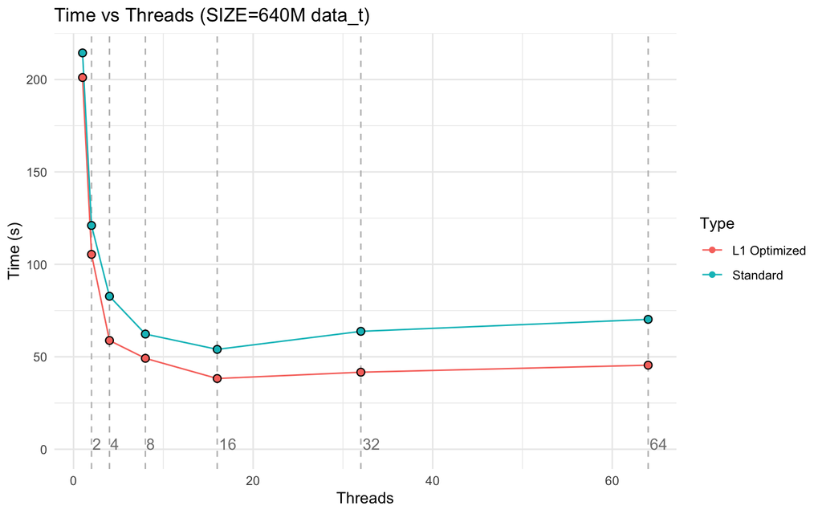

Speed-up vs number of threads:

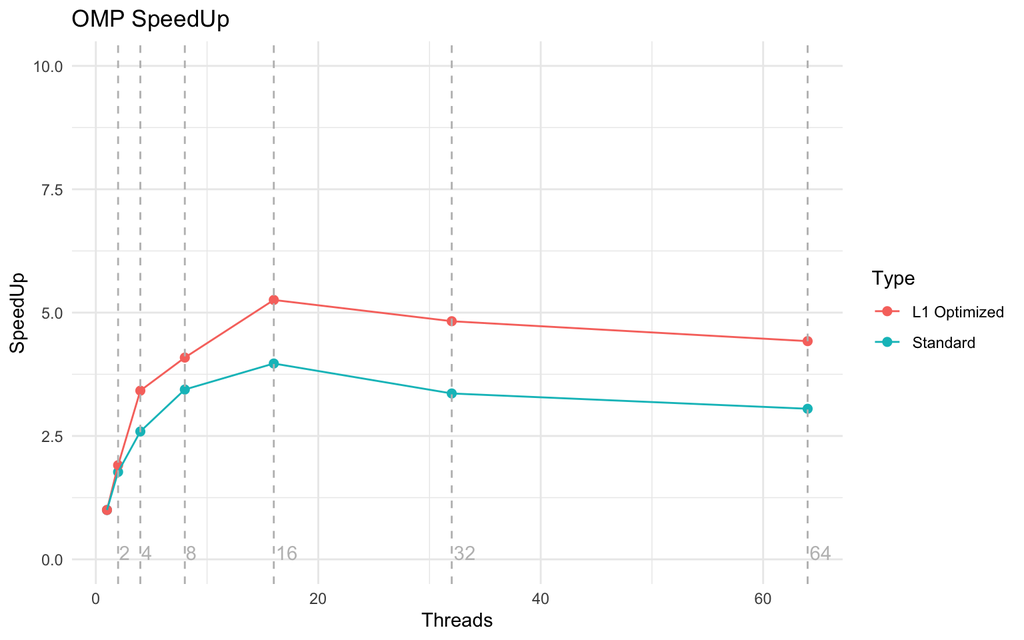

# Hybrid code: strong scalability

Given the time constraints on the ORFEO cluster I had to make 2 runs to get the data.

First import the data regarding processes from 1 to 64:

```r
strong_1half.df<- read.csv("../timings/StrongScalability_160M_1-64.csv")
strong_1half.df<- strong_1half.df %>%
                select(!Threads) %>%
                group_by(Processes) %>%
                summarise(Time = min(Time, na.rm = TRUE))
```

Then from 65 to 128:

```r
strong_2half.df<- read.csv("../timings/StrongScalability_160M_65-128.csv")
strong_2half.df<- strong_2half.df %>%
                select(!Threads) %>%
                group_by(Processes) %>%
                summarise(Time = min(Time, na.rm = TRUE))
```

And we merge the 2 df:

```r
strong.df<- rbind(strong_1half.df,strong_2half.df)
```

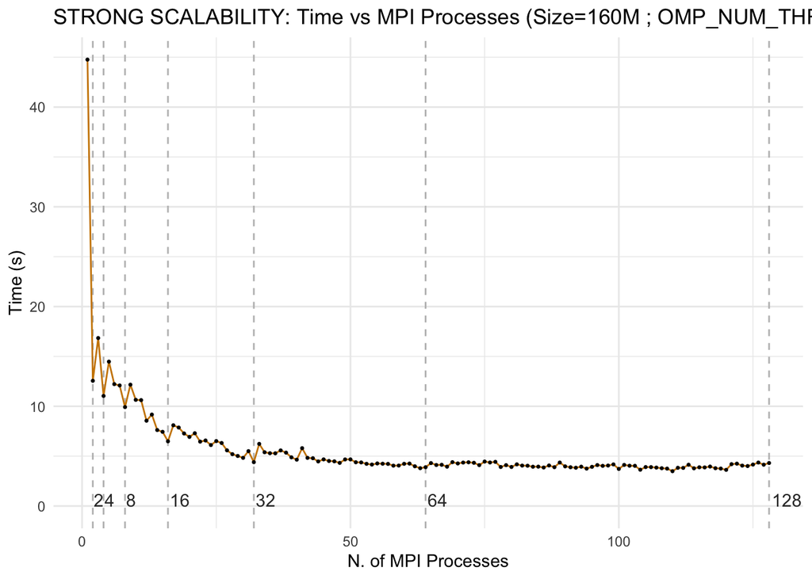

Notice how an odd number of processes influences negatively the sorting time:

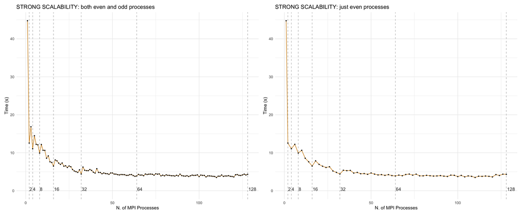

Strong scalability was considered also in terms of Speed-up:
$$Sp(N,P)= \frac{T_s(N)}{T_P(N)}$$
where $T_s(N)$ indicates the time to sort an array of size $N$ with the serial version of the algorithm, while $T_P(N)$ indicates the time to do the same with the parallelized version, run with $P$ processes

```r
strong.df$SpeedUp<- strong.df$Time[1] / strong.df$Time
```

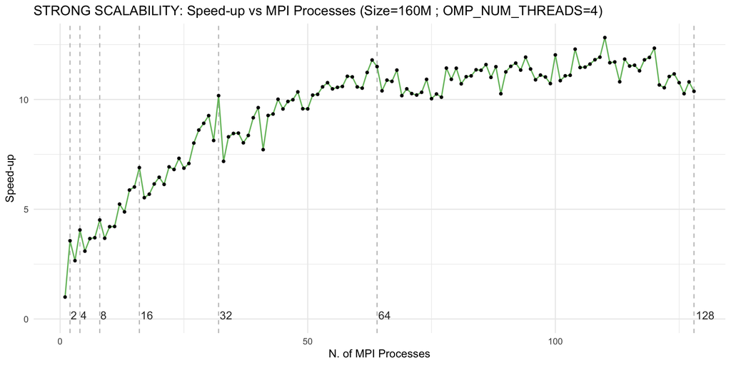

# Hybrid code: weak scalability

To evaluate the weak scalability of the algorithm, instead, we let the overall size $N$ vary keeping the workload-per-process as a constant. In this case, I opted for a workload of $2.500.000$ `size_t`

```r
weak_1half.df<- read.csv("../timings/WeakScalability_160M_1-64.csv")
weak_1half.df<- weak_1half.df %>%
                select(!Threads) %>%
                group_by(Processes) %>%
                summarise(Time = mean(Time, na.rm = TRUE))
```

```r
weak_2half.df<- read.csv("../timings/WeakScalability_160M_65-128.csv")
weak_2half.df<- weak_2half.df %>%
                select(!Threads) %>%
                group_by(Processes) %>%
                summarise(Time = mean(Time, na.rm = TRUE))
```

```r
weak.df<- rbind(weak_1half.df,weak_2half.df)
```

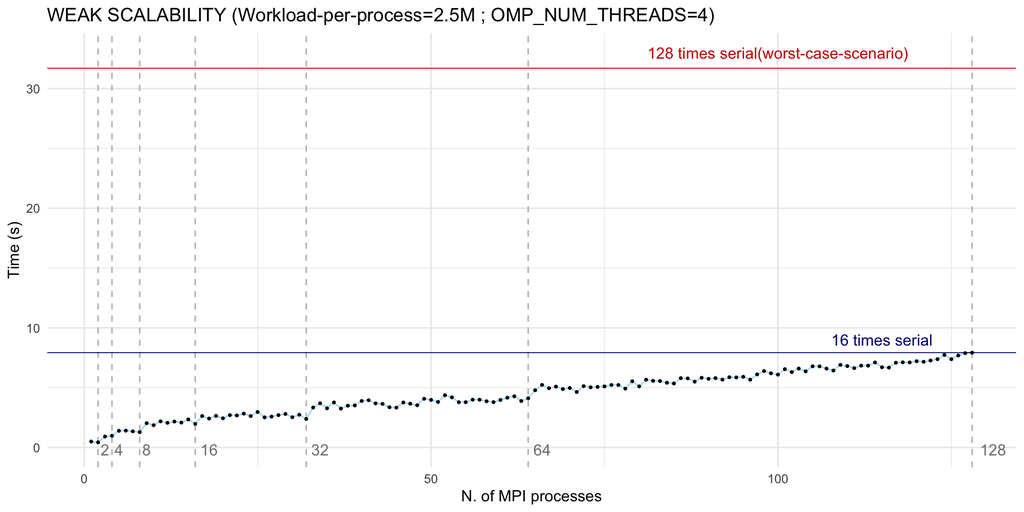